# Project - Communicate Data findings

### Indroduction

Ford Go Bike Syatem is a bike sharing system.Ford Go Bike System Provides service in San Francisco, East Bay and San Joe. Bicycle Sharing systems is very convenient sytem for those who want to take bicycle on rent for short visits.It is very affordable way to visits nearby places with the bicycle.

### About Dataset

I choose Ford Go Bike system Data that you can check from this link : https://www.fordgobike.com/system-data as my source data This data set includes information about individual rides made in a bike-sharing system.The features included in the dataset : Trip Duration (seconds) , Start-Time and Date , End-Time and Date , Start Station ID , Start Station Name , Start Station Latitude , Start Station Longitude , End Station ID , End Station Name, End Station Latitude , End Station Longitude , Bike ID , User Type (Subscriber or Customer – “Subscriber” = Member or “Customer” = Casual) , Member Year of Birth, Member Gender

I take data from **2017 to November 2018**

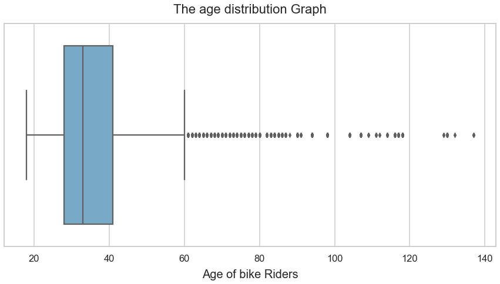

```python
# Now we plot the age distribution Box plot
# Using seaborn we create a box plot

#set style
sns.set_style('whitegrid')
sns.set_context("talk")

#plotting

plt.figure(figsize=(15,7))
sns.boxplot(x='member_age', data=df_ford1, palette='Blues', orient='h')
plt.title("The age distribution Graph", fontsize=22, y=1.03)
plt.xlabel("Age of bike Riders", fontsize=20, labelpad=10)
```

#### We can remove the outliers also beacuse we cantain some member in the dataset whose birth year is below 1900 and

#### his age become over 100 years so for my analysis i take the age group less than or egual to 60

###### Now our dataset is reduced

##### Again plot the distribution of age upto 60

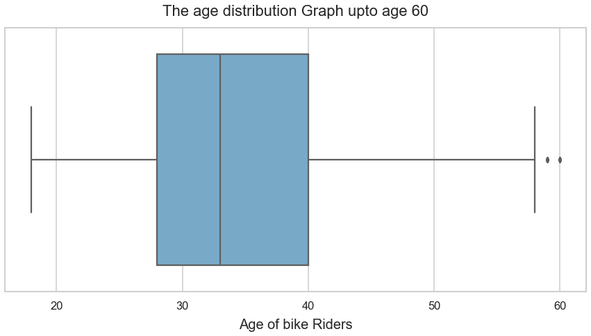

```python
#Now we again plot the graph
#set style
sns.set_style('whitegrid')
sns.set_context("talk")

#plotting

plt.figure(figsize=(15,7))
sns.boxplot(x='member_age', data=df_ford1, palette='Blues', orient='h')
plt.title("The age distribution Graph upto age 60", fontsize=22, y=1.03)
plt.xlabel("Age of bike Riders", fontsize=20, labelpad=10)
```

## What is the Structure of dataset ?

> Now we have **2032159** trip in the dataset with **22 columns** from **2017 to November 2018**

> Trip duration: start_time,end_time, how long the trip took in seconds

> Stations: start and end station id, name, geolocation (latitude/longitude)

> Customer data: gender, birth date and user type

> Rented bikes: bike id

> In the dataset I was further added few columns to find interesting analysis:

> Bike Time: month, day, hour of the day, weekday (both for start and end date)

> Customer: age

## What are the main features of interest in your dataset?

> My interest is to find who rides the bike most either male or female and the other thing i'm interested in is I want to know at which time the bikes in demand in weekdays or in weekend or in which month bikes has high demand

## What features in the dataset do you think will help support your investigation into your features of interest?

> According to my Dataset i think mostly i used the Start time in my analysis because i think that for which time the bike is rented or at which time the bikes is in demand are the most interesting thing to find in our dataset.

## Part-1 Univariate Exploration

### Question-1 In what hours Bike rented most (Hourly Rented Bikes) ?

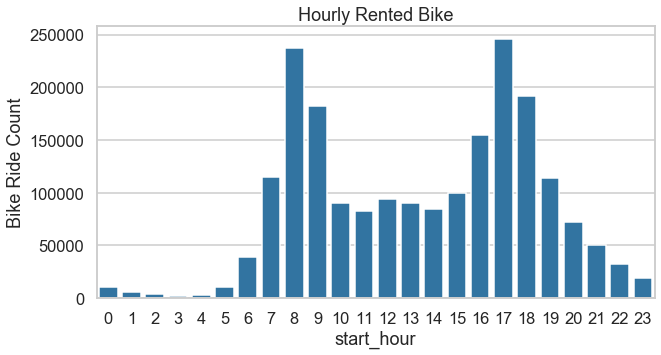

```python
#By Using seaborn i create plot
plt.figure(figsize = (10,5))
g = sns.countplot(data=df_ford1, x='start_hour',color =base_color);
g.set_title('Hourly Rented Bike');
g.set_ylabel('Bike Ride Count');
```

#### As we can see from the the graph that 17:00 hours that is 5pm bike rented the most

## Question-2 On which week of day Bike rides the most ?

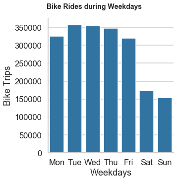

```python
#Create list of weekday
weekday = ['Mon', 'Tue', 'Wed', 'Thu', 'Fri', 'Sat', 'Sun']
g = sns.catplot(data=df_ford1, x='start_weekday', kind='count', color = base_color, order = weekday)
g.set_axis_labels("Weekdays", "Bike Trips")
g.fig.suptitle('Bike Rides during Weekdays', y=1.03, fontsize=14, fontweight='semibold');
```

### As we can see from the graogh that Tuesday has high Bike rides in comparison to all weekdays this means that people used to take bikes on weekdays to go to their respective workplaces or schools.

## Question-3 Which month has Highest bike rides ?

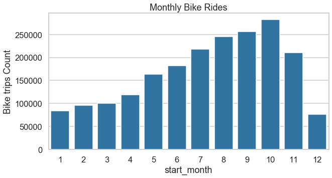

```python
plt.figure(figsize = (10,5))
g = sns.countplot(data=df_ford1, x='start_month',color =base_color);
g.set_title('Monthly Bike Rides');
g.set_ylabel('Bike trips Count');
```

### As we clearly see from the graph that Month 10 that is October has highest bike rides

## Question - 4 Which Age Group has most bike Rides ?

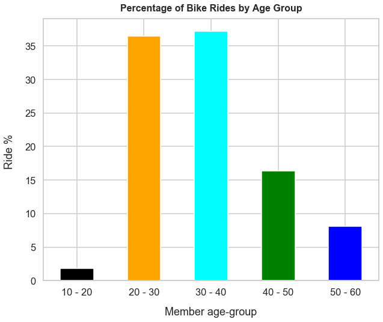

```python
#plot the graph
new_color = ['black', 'orange', 'cyan', 'green', 'blue']
trip_agegroup_df['percentage'].plot(kind='bar', color=new_color, figsize=(10,8))
plt.title('Percentage of Bike Rides by Age Group', fontsize=16, y=1.015,fontweight='semibold')
plt.xlabel('Member age-group', labelpad=16)
plt.ylabel('Ride % ', labelpad=16)
plt.xticks(rotation=360)
```

### As we clearly see from the Graph that Age group of 30-40 has most Rides percentage

### followed by age group of 20-30.

## Question -5 Percentage of Bike riders by gender ?

```
(0, 100)
```

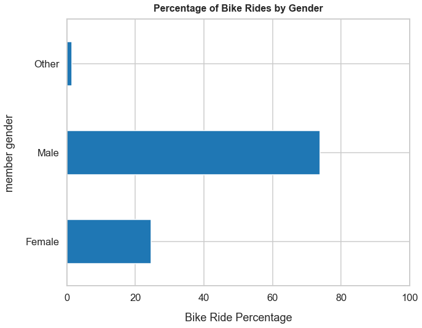

```python
#plotting graph
ride_gender_df['percentage'].plot(kind='barh', color=base_color, figsize=(10,8))
plt.title('Percentage of Bike Rides by Gender', fontsize=16, y=1.015,fontweight='semibold')
plt.ylabel('member gender', labelpad=16)
plt.xlabel('Bike Ride Percentage', labelpad=16)
plt.xticks(rotation=360)
plt.xlim(0,100)
```

### As we seen from the Graph about ~75% of Male Rides bike which is more than female and other category.

## Discuss the distribution(s) of your variable(s) of interest. Were there any unusual points? Did you need to perform any transformations

Firstly i visually asess the original dataframe then i make changes in it, because data is not ready to be used directly i require some cleaning efforts.I choose the dataframe which consists the member of age less than or equal to 60.so my dataframe reduced to 2032159 bike rides entry.

#### Some conclusion based on above visualization

- Month of october has highest bike rides
- About 75% of male rides bike which is more than female(25%)
- Age group of 30-40 rides the bikes most whereas age group 20-30 is growing age group
- People used this service more in weekdays rather than weekend , as Thuesday has highest bike Rides.
- Month of October has highest bike Rides.
- From 8-9am and 5-6pm people uses this Service Most.

## Of the features you investigated, were there any unusual distributions? Did you perform any operations on the data to tidy, adjust, or change the form of the data? If so, why did you do this?

There was one unusal distribution in the dataset that is member birth year has dates before 1900. There is 95% of the members are between 17 and 57 years. To keep the dataset simple,I removed members greater than 60 years old.And simplify my Dataset by keeping the member of Age is less than or equal to 60. I also generated new columns to calculate age members, weekdays,months,hours for my data analysis and clear visulization. I changed the data types of some columns .

## Part -2 Bivariate Exploration

### Question - 1 Average Trip Duration by User-Type

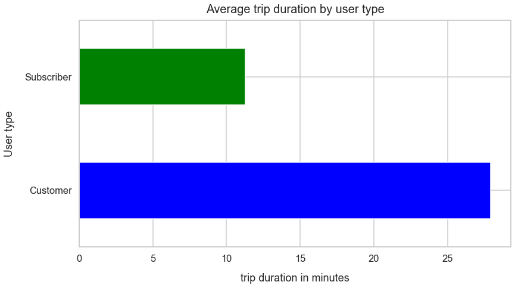

```python
colors=['blue', 'green']
axis = df_ford1.groupby('user_type')['duration_min'].mean().plot(kind='barh', color=colors, figsize=(13,7))
axis.set_title('Average trip duration by user type', fontsize=20, y=1.015)
axis.set_ylabel('User type', labelpad=16)
axis.set_xlabel('trip duration in minutes', labelpad=16)
```

### So as we clearly see from the graph that

> Average Subscriber's trip duration is **~11 minutes**

> Average Customer's trip duration is **~28 minutes**

### Question -2 Monthly user-type Trends

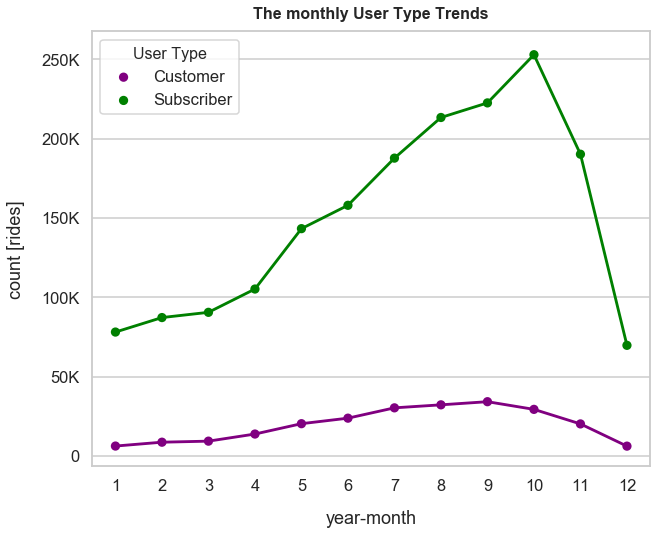

```python
#Plotting

plt.figure(figsize=(10,8))
colors = {'Subscriber':'Green', 'Customer':'purple'}
ax = sns.pointplot(x='start_month', y=0, hue='user_type', palette=colors, scale=.7, data=df_user_count)
plt.title('The monthly User Type Trends', fontsize=16, y=1.015,fontweight='semibold')
plt.xlabel('year-month', labelpad=16)
plt.ylabel('count [rides]', labelpad=16)
leg = ax.legend()
leg.set_title('User Type',prop={'size':16})
ax = plt.gca()
ax.yaxis.set_major_formatter(tick.FuncFormatter(transform_axis_fmt))
```

## Question -3 Weekly usage Trends by the User-type?

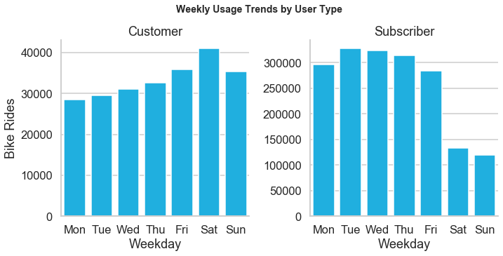

```python
weekday = ['Mon', 'Tue', 'Wed', 'Thu', 'Fri', 'Sat', 'Sun']
g = sns.catplot(data=df_ford1, x='start_weekday', col="user_type", kind='count', sharey = False,
            color = 'deepskyblue', order = weekday)
g.set_axis_labels("Weekday", "Bike Rides")
g.set_titles("{col_name}")
g.fig.suptitle('Weekly Usage Trends by User Type', y=1.03, fontsize=14, fontweight='semibold');
```

#### Above Graph shows the difference between Customers and subscribers they take the Bike rides on weekdays.

## Question -4 Average Bike - trip Distance of Subscribes Vs Customers ?

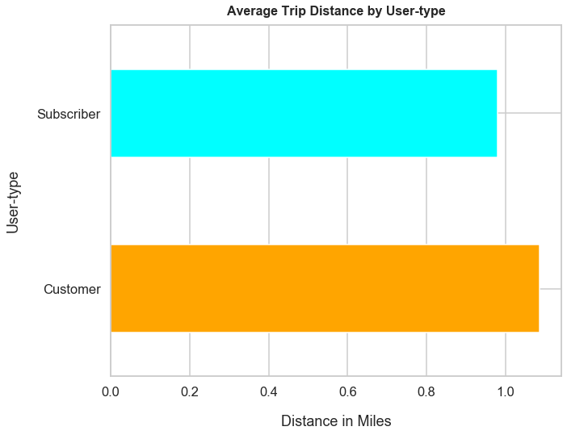

```python
new_color= ['orange','cyan']
ax = df_ford1.groupby('user_type')['distance_miles'].mean().plot(kind='barh', color=new_color, figsize=(10,8))
ax.set_title('Average Trip Distance by User-type', fontsize=16, y=1.015,fontweight='semibold')
ax.set_ylabel('User-type', labelpad=20)
ax.set_xlabel('Distance in Miles', labelpad=20)
```

## Part -3 Multivariate Exploration

### Question-1 Bike Rides by Gender ?

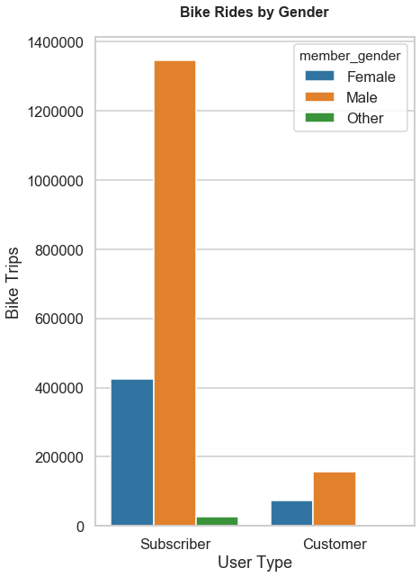

```python
#setting figure Size

plt.figure(figsize = [14, 10])

# code for the bar chart
plt.subplot(1, 2, 1)

g = sns.countplot(data=df_ford1, x="user_type", hue="member_gender", order=df_ford1.user_type.value_counts().index)
g.set_xlabel('User Type')
g.set_ylabel('Bike Trips')
g.set_title('Bike Rides by Gender', y=1.03, fontsize=16, fontweight='semibold');
```

#### As by seeing the above graph we clearly see that males using the service more rather than females or Others category.

## Question -2 Monthly Bike Trends By the User-type?

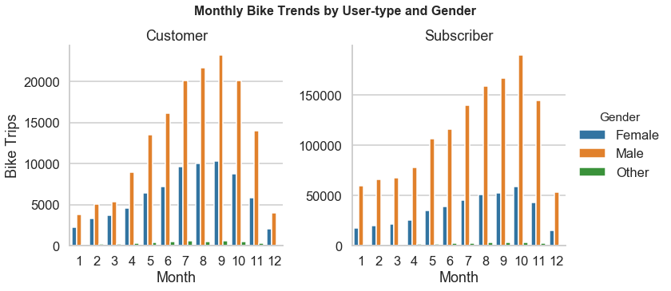

```python
g = sns.catplot(data=df_ford1, x='start_month', col="user_type", hue="member_gender", kind='count', sharey = False)
g.set_axis_labels("Month", "Bike Trips")
g._legend.set_title('Gender')
g.set_titles("{col_name}")
g.fig.suptitle('Monthly Bike Trends by User-type and Gender', y=1.03, fontsize=16, fontweight='semibold');
```

#### As we can easily see from the above Graph that may to octobers trips are increasing but decreases in winter

## Question -3 Bike trips By subscribers member age group ?

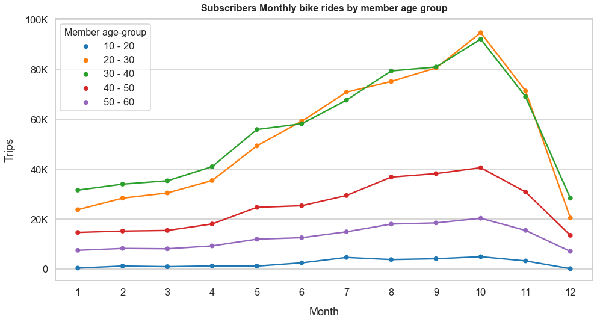

```python
#plotting the multivariate Graph

plt.figure(figsize=(16,8))
ax = sns.pointplot(x='start_month', y='bike_id', hue='member_age_bins', scale=.6, data=df_subs)
plt.title("Subscribers Monthly bike rides by member age group", fontsize=16, y=1.015,fontweight='semibold')
plt.xlabel('Month', labelpad=16)
plt.ylabel('Trips', labelpad=16)
leg = ax.legend()
leg.set_title('Member age-group',prop={'size':16})
ax = plt.gca()
ax.yaxis.set_major_formatter(tick.FuncFormatter(transform_axis_fmt))
```

## Question - 4 Bike trips by Customer member age-group ?

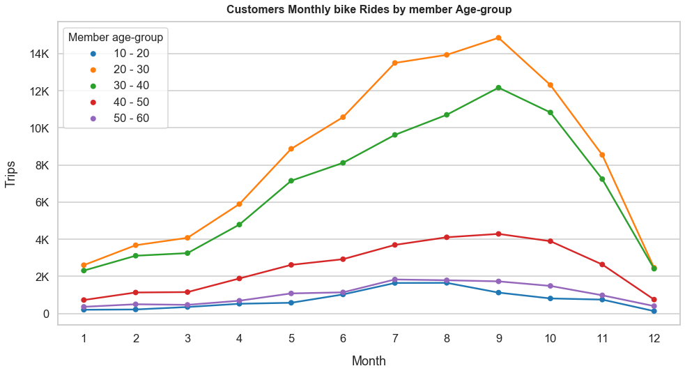

```python
#Plotting

plt.figure(figsize=(16,8))
ax = sns.pointplot(x='start_month', y='bike_id', hue='member_age_bins', scale=.6, data=df_cust)
plt.title("Customers Monthly bike Rides by member Age-group", fontsize=16, y=1.015,fontweight='semibold')
plt.xlabel('Month', labelpad=16)
plt.ylabel('Trips', labelpad=16)
leg = ax.legend()
leg.set_title('Member age-group',prop={'size':16})
ax = plt.gca()
ax.yaxis.set_major_formatter(tick.FuncFormatter(transform_axis_fmt))
```

## Question -5 Bike trends of subscriber By Age, Weekdays,Hour Analysis

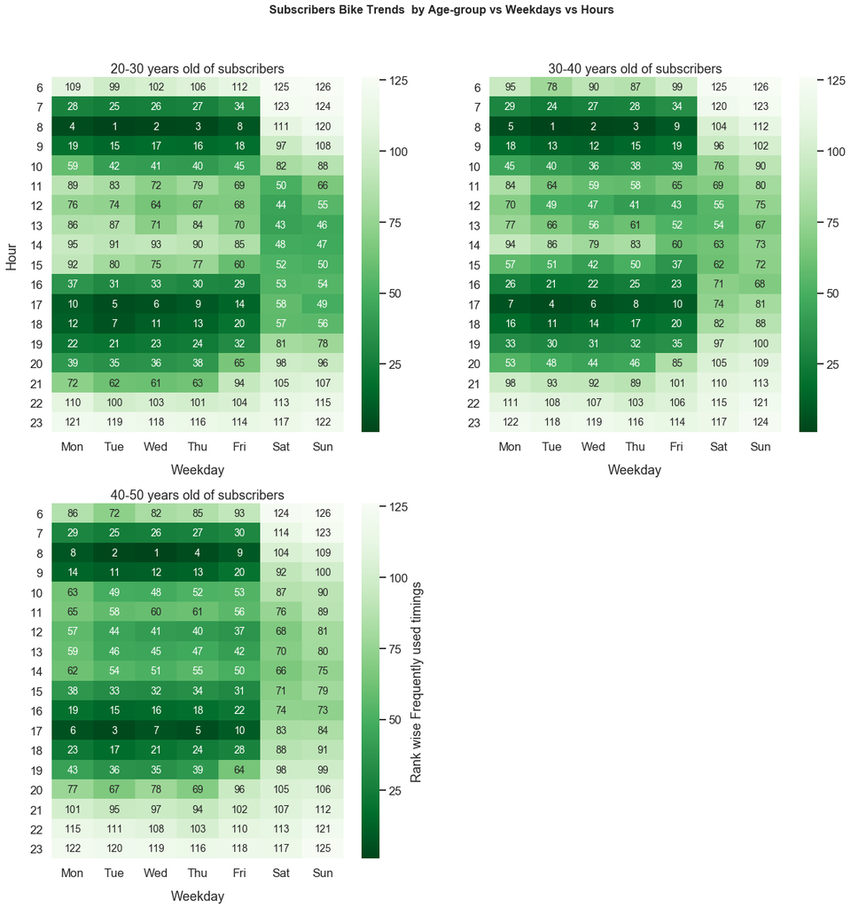

```python
plt.figure(figsize=(20,20))
plt.subplot(221)
plt.suptitle(' Subscribers Bike Trends  by Age-group vs Weekdays vs Hours', fontsize=16,fontweight='semibold', y=0.95)
sns.heatmap(pivot2_subs, fmt='d', annot=True, cmap='Greens_r', annot_kws={"size": 14})
plt.title("20-30 years old of subscribers", y=1.015)
plt.xlabel('Weekday', labelpad=16)
plt.ylabel('Hour', labelpad=16)
plt.yticks(rotation=360)
plt.subplot(222)
sns.heatmap(pivot3_subs, fmt='d', annot=True, cmap='Greens_r', annot_kws={"size": 14})
plt.title("30-40 years old of subscribers", y=1.015)
plt.xlabel('Weekday', labelpad=16)
plt.ylabel(' ')
plt.yticks(rotation=360)
plt.subplot(223)
sns.heatmap(pivot4_subs, fmt='d', annot=True, cmap='Greens_r', annot_kws={"size": 14}, cbar_kws={'label': 'Rank wise Frequently used timings'})
plt.title("40-50 years old of subscribers", y=1.015)
plt.xlabel('Weekday', labelpad=16)
plt.ylabel(' ')
plt.yticks(rotation=360)
```

##### By seeing the above heatmaps of all 20-30,30-40,40-50 age group years of subscribers use service from Monday to Friday during 7-9am and at 5pm has highest traffic. Subscribers are less active on weekend saturday sunday.This shows that they will just use the service for going to their workplaces or schools.

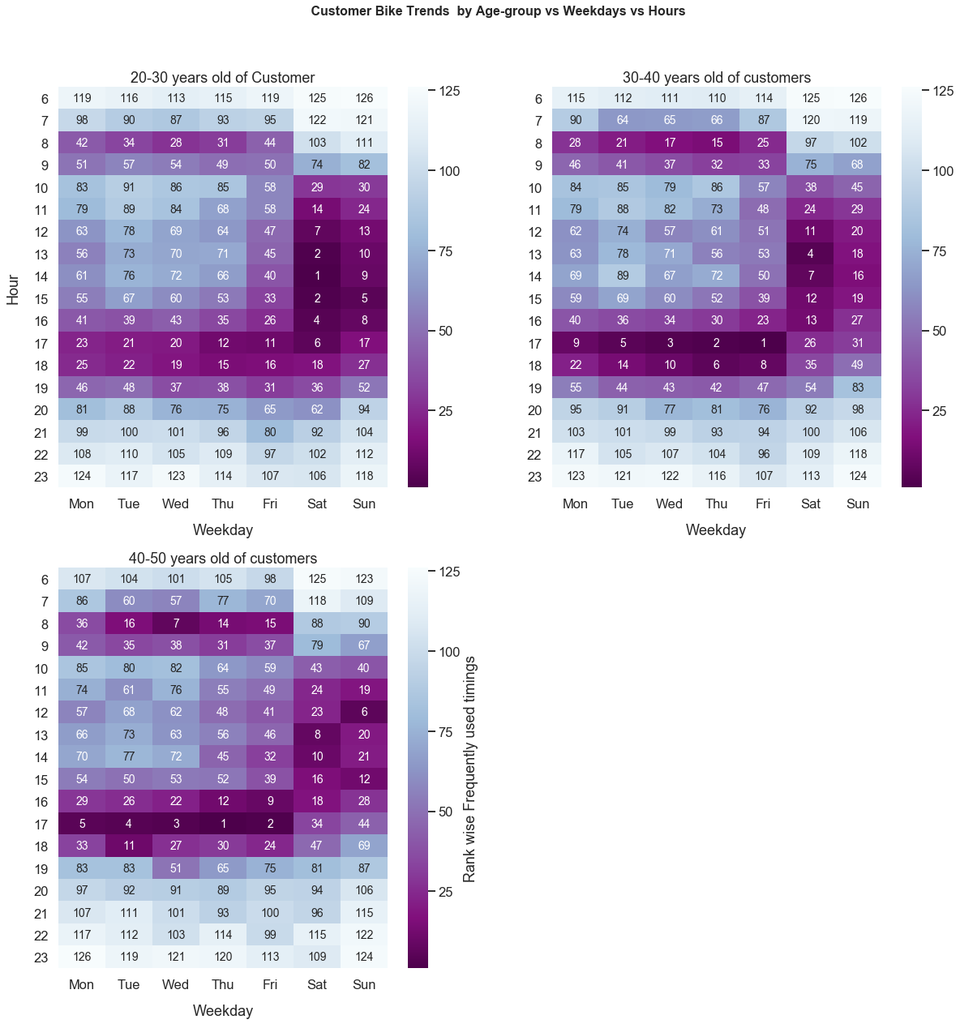

```python
plt.figure(figsize=(20,20))
plt.subplot(221)
plt.suptitle(' Customer Bike Trends  by Age-group vs Weekdays vs Hours', fontsize=16,fontweight='semibold', y=0.95)
sns.heatmap(pivot2_cust, fmt='d', annot=True, cmap='BuPu_r', annot_kws={"size": 14})
plt.title("20-30 years old of Customer", y=1.015)
plt.xlabel('Weekday', labelpad=16)
plt.ylabel('Hour', labelpad=16)
plt.yticks(rotation=360)
plt.subplot(222)
sns.heatmap(pivot3_cust, fmt='d', annot=True, cmap='BuPu_r', annot_kws={"size": 14})
plt.title("30-40 years old of customers", y=1.015)
plt.xlabel('Weekday', labelpad=16)
plt.ylabel(' ')
plt.yticks(rotation=360)
plt.subplot(223)
sns.heatmap(pivot4_cust, fmt='d', annot=True, cmap='BuPu_r', annot_kws={"size": 14}, cbar_kws={'label': 'Rank wise Frequently used timings'})
plt.title("40-50 years old of customers", y=1.015)
plt.xlabel('Weekday', labelpad=16)
plt.ylabel(' ')
plt.yticks(rotation=360)
```

## Talk about some of the relationships you observed in this part of the investigation. Were there features that strengthened each other in terms of looking at your feature(s) of interest?

Here in multivariate Exploration Part i analyse the difference the different age-groups of subscribers and customers rides bikes on weekend, hourly. All this work done under Multivariate Exploration Part.by seeing the subscriber heatmap of different age group i observed that subscribers uses the service for going their respective workplaces and schools and offices and during in the 7-9am in morning and 5pm in evening has highest traffic and they uses the service in weekdays more than weekends. whereas As we see the Customer heat maps of different age-groups.and i observe that customer uses the service more on weekends.in morning 8-9am and 4-5pm in the evening.

## Were there any interesting or surprising interactions between features?

#### The thing which is surprising is that yougsters uses this service and it is continuosly growing the people of age group 20-30 and 30-40 uses the service most. it is quite amazing that Some people that we called subscribers they used the service most on weekdays where some people that we called customers they used this service more on weekends.

## Conclusion :

I considered 2018 data from 2017 to November 2018.the user of Age-group of 20-30 years are rapidly growing compared to other user groups. First service is started with 30-40 years users and followed by 20-30 yrs age group who became dominant over the year.

Males uses the service Most in comaprison to females.

Age-group of 20-30 is rapidly growing group

This all conclusions is based on my analysis and I take dataset of member whose age is less than or equal to 60.